# Final Project Predictive Analytics Test

Author

Sora Hosoda

Published

August 12, 2026

# Setup

```r
library(tidymodels)
library(tidyverse)
library(xgboost)
library(vip)

tidymodels_prefer()

set.seed(2025)
```

# Data

```r
marketing_data <- read_csv(
  "digital_marketing_campaign_dataset.csv"
)

glimpse(marketing_data)
```

```
Rows: 8,000
Columns: 20
$ CustomerID          <dbl> 8000, 8001, 8002, 8003, 8004, 8005, 8006, 8007, 80…
$ Age                 <dbl> 56, 69, 46, 32, 60, 25, 38, 56, 36, 40, 28, 28, 41…
$ Gender              <chr> "Female", "Male", "Female", "Female", "Female", "F…
$ Income              <dbl> 136912, 41760, 88456, 44085, 83964, 42925, 25615, …
$ CampaignChannel     <chr> "Social Media", "Email", "PPC", "PPC", "PPC", "Soc…
$ CampaignType        <chr> "Awareness", "Retention", "Awareness", "Conversion…
$ AdSpend             <dbl> 6497.8701, 3898.6686, 1546.4296, 539.5259, 1678.04…
$ ClickThroughRate    <dbl> 0.04391851, 0.15572507, 0.27749037, 0.13761125, 0.…
$ ConversionRate      <dbl> 0.08803141, 0.18272468, 0.07642272, 0.08800419, 0.…
$ WebsiteVisits       <dbl> 0, 42, 2, 47, 0, 6, 42, 48, 13, 22, 47, 16, 13, 8,…
$ PagesPerVisit       <dbl> 2.399017, 2.917138, 8.223619, 4.540939, 2.046847, …
$ TimeOnSite          <dbl> 7.396803, 5.352549, 13.794901, 14.688363, 13.99337…
$ SocialShares        <dbl> 19, 5, 0, 89, 6, 95, 54, 96, 73, 14, 94, 23, 28, 8…
$ EmailOpens          <dbl> 6, 2, 11, 2, 6, 5, 14, 9, 4, 8, 16, 18, 16, 8, 16,…
$ EmailClicks         <dbl> 9, 7, 2, 2, 6, 8, 3, 3, 8, 4, 5, 6, 5, 1, 8, 1, 8,…
$ PreviousPurchases   <dbl> 4, 2, 8, 0, 8, 0, 6, 0, 5, 8, 6, 5, 4, 2, 1, 1, 8,…
$ LoyaltyPoints       <dbl> 688, 3459, 2337, 2463, 4345, 3316, 930, 2983, 460,…
$ AdvertisingPlatform <chr> "IsConfid", "IsConfid", "IsConfid", "IsConfid", "I…
$ AdvertisingTool     <chr> "ToolConfid", "ToolConfid", "ToolConfid", "ToolCon…
$ Conversion          <dbl> 1, 1, 1, 1, 1, 1, 1, 1, 1, 1, 1, 1, 1, 1, 1, 0, 1,…
```

# Analytics Objective

> To develop a predictive model that identifies the most useful factors for predicting customer conversion using customer demographics, campaign information, engagement variables, and purchase history.
- **Learning type:** Supervised learning
- **Outcome:** `Conversion`
- **Broader method:** Classification

# Data Check

```r
marketing_data |>
  summarise(
    rows = n(),
    columns = ncol(marketing_data),
    missing_values = sum(is.na(marketing_data)),
    duplicate_rows = sum(duplicated(marketing_data))
  )
```

```
# A tibble: 1 × 4
   rows columns missing_values duplicate_rows
  <int>   <int>          <int>          <int>
1  8000      20              0              0
```

# Outcome Distribution

```r
marketing_data |>
  count(Conversion) |>
  mutate(
    proportion = n / sum(n)
  )
```

```
# A tibble: 2 × 3
  Conversion     n proportion
       <dbl> <int>      <dbl>
1          0   988      0.124
2          1  7012      0.876
```

# Train/Test Split

```r
marketing_data <- marketing_data |>
  mutate(
    Conversion = factor(
      Conversion,
      levels = c(1, 0),
      labels = c("Yes", "No")
    )
  )

set.seed(617)

marketing_split <- initial_split(
  marketing_data,
  prop = 0.80,
  strata = Conversion
)

marketing_train <- training(marketing_split)
marketing_test <- testing(marketing_split)

cat(
  "Training rows:",
  nrow(marketing_train),
  "\n"
)
```

```
Training rows: 6399
```

```r
cat(
  "Test rows    :",
  nrow(marketing_test),
  "\n"
)
```

```
Test rows    : 1601
```

```r
marketing_train |>
  count(Conversion) |>
  mutate(
    proportion = n / sum(n)
  )
```

```
# A tibble: 2 × 3
  Conversion     n proportion
  <fct>      <int>      <dbl>
1 Yes         5609      0.877
2 No           790      0.123
```

```r
marketing_test |>
  count(Conversion) |>
  mutate(
    proportion = n / sum(n)
  )
```

```
# A tibble: 2 × 3
  Conversion     n proportion
  <fct>      <int>      <dbl>
1 Yes         1403      0.876
2 No           198      0.124
```

# Recipe

```r
conversion_rec <- recipe(
  Conversion ~
    Age +
    Gender +
    Income +
    CampaignChannel +
    CampaignType +
    AdSpend +
    ClickThroughRate +
    WebsiteVisits +
    PagesPerVisit +
    TimeOnSite +
    SocialShares +
    EmailOpens +
    EmailClicks +
    PreviousPurchases +
    LoyaltyPoints,
  data = marketing_train
) |>
  step_impute_median(
    all_numeric_predictors()
  ) |>
  step_dummy(
    all_nominal_predictors()
  ) |>
  step_zv(
    all_predictors()
  ) |>
  step_nzv(
    all_predictors()
  ) |>
  step_normalize(
    all_numeric_predictors()
  )

conversion_rec
```

# Baseline Classification Model

## Logistic Regression

```r
logistic_spec <- logistic_reg() |>
  set_engine("glm") |>
  set_mode("classification")

logistic_wf <- workflow() |>
  add_recipe(conversion_rec) |>
  add_model(logistic_spec)

logistic_fit <- fit(
  logistic_wf,
  data = marketing_train
)

logistic_fit
```

```
══ Workflow [trained] ══════════════════════════════════════════════════════════
Preprocessor: Recipe
Model: logistic_reg()

── Preprocessor ────────────────────────────────────────────────────────────────
5 Recipe Steps

• step_impute_median()
• step_dummy()
• step_zv()
• step_nzv()
• step_normalize()

── Model ───────────────────────────────────────────────────────────────────────

Call:  stats::glm(formula = ..y ~ ., family = stats::binomial, data = data)

Coefficients:
                 (Intercept)                           Age
                    -2.50603                      -0.01239
                      Income                       AdSpend
                    -0.07751                      -0.43744
            ClickThroughRate                 WebsiteVisits
                    -0.44336                      -0.31420
               PagesPerVisit                    TimeOnSite
                    -0.36999                      -0.43341
                SocialShares                    EmailOpens
                     0.05185                      -0.43462
                 EmailClicks             PreviousPurchases
                    -0.47679                      -0.37476
               LoyaltyPoints                   Gender_Male
                    -0.35641                      -0.04352
         CampaignChannel_PPC      CampaignChannel_Referral
                    -0.08023                      -0.09780
         CampaignChannel_SEO  CampaignChannel_Social.Media
                    -0.08387                      -0.03219
  CampaignType_Consideration       CampaignType_Conversion
                    -0.03896                      -0.46508
      CampaignType_Retention
                    -0.02809

Degrees of Freedom: 6398 Total (i.e. Null);  6378 Residual
Null Deviance:      4783
Residual Deviance: 3910     AIC: 3952
```

# Model Evaluation

## Logistic Regression Evaluation

```r
logistic_preds <- augment(
  logistic_fit,
  new_data = marketing_test
)

logistic_preds |>
  metric_set(
    accuracy,
    roc_auc,
    sens,
    spec
  )(
    truth = Conversion,
    estimate = .pred_class,
    .pred_Yes
  )
```

```
# A tibble: 4 × 3
  .metric  .estimator .estimate
  <chr>    <chr>          <dbl>
1 accuracy binary         0.896
2 sens     binary         0.996
3 spec     binary         0.187
4 roc_auc  binary         0.810
```

```r
conf_mat(
  logistic_preds,
  truth = Conversion,
  estimate = .pred_class
)
```

```
          Truth
Prediction  Yes   No
       Yes 1398  161
       No     5   37
```

# Alternative Models

## Decision Tree

### Tree Recipe

```r
tree_rec <- recipe(
  Conversion ~
    Age +
    Gender +
    Income +
    CampaignChannel +
    CampaignType +
    AdSpend +
    ClickThroughRate +
    WebsiteVisits +
    PagesPerVisit +
    TimeOnSite +
    SocialShares +
    EmailOpens +
    EmailClicks +
    PreviousPurchases +
    LoyaltyPoints,
  data = marketing_train
) |>
  step_impute_median(
    all_numeric_predictors()
  ) |>
  step_novel(
    all_nominal_predictors()
  ) |>
  step_unknown(
    all_nominal_predictors()
  ) |>
  step_zv(
    all_predictors()
  )

tree_rec
```

### Decision Tree Model

```r
tree_spec <- decision_tree(
  cost_complexity = 0.001,
  tree_depth = 10,
  min_n = 20
) |>
  set_engine("rpart") |>
  set_mode("classification")

tree_wf <- workflow() |>
  add_recipe(tree_rec) |>
  add_model(tree_spec)

tree_fit <- fit(
  tree_wf,
  data = marketing_train
)

tree_fit
```

```
══ Workflow [trained] ══════════════════════════════════════════════════════════
Preprocessor: Recipe
Model: decision_tree()

── Preprocessor ────────────────────────────────────────────────────────────────
4 Recipe Steps

• step_impute_median()
• step_novel()
• step_unknown()
• step_zv()

── Model ───────────────────────────────────────────────────────────────────────
n= 6399

node), split, n, loss, yval, (yprob)
      * denotes terminal node

  1) root 6399 790 Yes (0.87654321 0.12345679)
    2) PreviousPurchases>=1.5 5068 483 Yes (0.90469613 0.09530387)
      4) PagesPerVisit>=2.994787 3984 296 Yes (0.92570281 0.07429719)
        8) EmailClicks>=1.5 3196 195 Yes (0.93898623 0.06101377)
         16) TimeOnSite>=4.886756 2235 108 Yes (0.95167785 0.04832215) *
         17) TimeOnSite< 4.886756 961  87 Yes (0.90946930 0.09053070)
           34) ClickThroughRate>=0.1102621 629  38 Yes (0.93958665 0.06041335)
             68) WebsiteVisits>=8.5 519  23 Yes (0.95568401 0.04431599) *
             69) WebsiteVisits< 8.5 110  15 Yes (0.86363636 0.13636364)
              138) AdSpend>=4382.819 59   1 Yes (0.98305085 0.01694915) *
              139) AdSpend< 4382.819 51  14 Yes (0.72549020 0.27450980)
                278) LoyaltyPoints>=1085.5 42   7 Yes (0.83333333 0.16666667) *
                279) LoyaltyPoints< 1085.5 9   2 No (0.22222222 0.77777778) *
           35) ClickThroughRate< 0.1102621 332  49 Yes (0.85240964 0.14759036)
             70) EmailOpens>=3.5 266  27 Yes (0.89849624 0.10150376)
              140) LoyaltyPoints>=1003.5 206  14 Yes (0.93203883 0.06796117) *
              141) LoyaltyPoints< 1003.5 60  13 Yes (0.78333333 0.21666667)
                282) AdSpend>=4950.846 37   0 Yes (1.00000000 0.00000000) *
                283) AdSpend< 4950.846 23  10 No (0.43478261 0.56521739)
                  566) CampaignType=Consideration,Conversion 13   4 Yes (0.69230769 0.30769231) *
                  567) CampaignType=Awareness,Retention 10   1 No (0.10000000 0.90000000) *
             71) EmailOpens< 3.5 66  22 Yes (0.66666667 0.33333333)
```

[output cut: 11 more lines]

```
              146) ClickThroughRate>=0.09455677 95  10 Yes (0.89473684 0.10526316) *
              147) ClickThroughRate< 0.09455677 32  12 Yes (0.62500000 0.37500000)
                294) EmailOpens>=5.5 25   6 Yes (0.76000000 0.24000000)
                  588) AdSpend>=2467.33 18   2 Yes (0.88888889 0.11111111) *
                  589) AdSpend< 2467.33 7   3 No (0.42857143 0.57142857) *
                295) EmailOpens< 5.5 7   1 No (0.14285714 0.85714286) *
           37) LoyaltyPoints< 867 113  26 Yes (0.76991150 0.23008850)
             74) ClickThroughRate>=0.07653799 91  13 Yes (0.85714286 0.14285714) *
             75) ClickThroughRate< 0.07653799 22   9 No (0.40909091 0.59090909)
              150) CampaignChannel=Referral,SEO 8   2 Yes (0.75000000 0.25000000) *
              151) CampaignChannel=Email,PPC,Social Media 14   3 No (0.21428571 0.78571429) *
         19) AdSpend< 931.2927 68  23 Yes (0.66176471 0.33823529)

...
and 118 more lines.
```

### Decision Tree Evaluation

```r
tree_preds <- augment(
  tree_fit,
  new_data = marketing_test
)

tree_preds |>
  metric_set(
    accuracy,
    roc_auc,
    sens,
    spec
  )(
    truth = Conversion,
    estimate = .pred_class,
    .pred_Yes
  )
```

```
# A tibble: 4 × 3
  .metric  .estimator .estimate
  <chr>    <chr>          <dbl>
1 accuracy binary         0.884
2 sens     binary         0.959
3 spec     binary         0.354
4 roc_auc  binary         0.725
```

```r
conf_mat(
  tree_preds,
  truth = Conversion,
  estimate = .pred_class
)
```

```
          Truth
Prediction  Yes   No
       Yes 1346  128
       No    57   70
```

# 10-Fold Cross-Validation

## Cross-Validation Folds

```r
set.seed(2025)

conversion_folds <- vfold_cv(
  marketing_train,
  v = 10,
  strata = Conversion
)

conversion_folds
```

```
#  10-fold cross-validation using stratification
# A tibble: 10 × 2
   splits             id
   <list>             <chr>
 1 <split [5759/640]> Fold01
 2 <split [5759/640]> Fold02
 3 <split [5759/640]> Fold03
 4 <split [5759/640]> Fold04
 5 <split [5759/640]> Fold05
 6 <split [5759/640]> Fold06
 7 <split [5759/640]> Fold07
 8 <split [5759/640]> Fold08
 9 <split [5759/640]> Fold09
10 <split [5760/639]> Fold10
```

# Random Forest

## Random Forest Specification and Tuning

```r
rf_grid <- tibble(
  mtry = c(5L, 10L),
  min_n = c(10L, 30L)
)

rf_spec <- rand_forest(
  mtry = tune(),
  min_n = tune(),
  trees = 100
) |>
  set_engine(
    "ranger",
    importance = "permutation"
  ) |>
  set_mode("classification")

rf_wf <- workflow() |>
  add_recipe(tree_rec) |>
  add_model(rf_spec)

set.seed(2025)

rf_results <- tune_grid(
  rf_wf,
  resamples = conversion_folds,
  grid = rf_grid,
  metrics = metric_set(
    roc_auc,
    accuracy
  )
)
```

## Best Random Forest Parameters

```r
rf_best <- select_best(
  rf_results,
  metric = "roc_auc"
)

rf_best
```

```
# A tibble: 1 × 3
   mtry min_n .config
  <int> <int> <chr>
1     5    10 pre0_mod1_post0
```

```r
show_best(
  rf_results,
  metric = "roc_auc",
  n = 2
)
```

```
# A tibble: 2 × 8
   mtry min_n .metric .estimator  mean     n std_err .config
  <int> <int> <chr>   <chr>      <dbl> <int>   <dbl> <chr>
1     5    10 roc_auc binary     0.795    10  0.0137 pre0_mod1_post0
2    10    30 roc_auc binary     0.788    10  0.0137 pre0_mod2_post0
```

## Final Random Forest Model

```r
final_rf_wf <- finalize_workflow(
  rf_wf,
  rf_best
)

final_rf_fit <- fit(
  final_rf_wf,
  data = marketing_train
)

final_rf_fit
```

```
══ Workflow [trained] ══════════════════════════════════════════════════════════
Preprocessor: Recipe
Model: rand_forest()

── Preprocessor ────────────────────────────────────────────────────────────────
4 Recipe Steps

• step_impute_median()
• step_novel()
• step_unknown()
• step_zv()

── Model ───────────────────────────────────────────────────────────────────────
Ranger result

Call:
 ranger::ranger(x = maybe_data_frame(x), y = y, mtry = min_cols(~5L,      x), num.trees = ~100, min.node.size = min_rows(~10L, x),      importance = ~"permutation", num.threads = 1, verbose = FALSE,      seed = sample.int(10^5, 1), probability = TRUE)

Type:                             Probability estimation
Number of trees:                  100
Sample size:                      6399
Number of independent variables:  15
Mtry:                             5
Target node size:                 10
Variable importance mode:         permutation
Splitrule:                        gini
OOB prediction error (Brier s.):  0.08465889
```

## Random Forest Evaluation

```r
rf_preds <- augment(
  final_rf_fit,
  new_data = marketing_test
)

rf_preds |>
  metric_set(
    accuracy,
    roc_auc,
    sens,
    spec
  )(
    truth = Conversion,
    estimate = .pred_class,
    .pred_Yes
  )
```

```
# A tibble: 4 × 3
  .metric  .estimator .estimate
  <chr>    <chr>          <dbl>
1 accuracy binary         0.901
2 sens     binary         0.993
3 spec     binary         0.247
4 roc_auc  binary         0.825
```

```r
conf_mat(
  rf_preds,
  truth = Conversion,
  estimate = .pred_class
)
```

```
          Truth
Prediction  Yes   No
       Yes 1393  149
       No    10   49
```

# XGBoost

## XGBoost Recipe

```r
xgb_rec <- recipe(
  Conversion ~
    Age +
    Gender +
    Income +
    CampaignChannel +
    CampaignType +
    AdSpend +
    ClickThroughRate +
    WebsiteVisits +
    PagesPerVisit +
    TimeOnSite +
    SocialShares +
    EmailOpens +
    EmailClicks +
    PreviousPurchases +
    LoyaltyPoints,
  data = marketing_train
) |>
  step_impute_median(
    all_numeric_predictors()
  ) |>
  step_novel(
    all_nominal_predictors()
  ) |>
  step_unknown(
    all_nominal_predictors()
  ) |>
  step_dummy(
    all_nominal_predictors(),
    one_hot = TRUE
  ) |>
  step_zv(
    all_predictors()
  )

xgb_rec
```

## XGBoost Specification

```r
xgb_spec <- boost_tree(
  trees = 300,
  tree_depth = tune(),
  learn_rate = tune(),
  min_n = tune()
) |>
  set_engine("xgboost") |>
  set_mode("classification")

xgb_wf <- workflow() |>
  add_recipe(xgb_rec) |>
  add_model(xgb_spec)

xgb_wf
```

```
══ Workflow ════════════════════════════════════════════════════════════════════
Preprocessor: Recipe
Model: boost_tree()

── Preprocessor ────────────────────────────────────────────────────────────────
5 Recipe Steps

• step_impute_median()
• step_novel()
• step_unknown()
• step_dummy()
• step_zv()

── Model ───────────────────────────────────────────────────────────────────────
Boosted Tree Model Specification (classification)

Main Arguments:
  trees = 300
  min_n = tune()
  tree_depth = tune()
  learn_rate = tune()

Computational engine: xgboost
```

## XGBoost Tuning

```r
xgb_grid <- tibble(
  tree_depth = c(
    2L,
    4L,
    4L,
    6L
  ),
  learn_rate = c(
    0.01,
    0.01,
    0.05,
    0.05
  ),
  min_n = c(
    5L,
    15L,
    15L,
    30L
  )
)

set.seed(2025)

xgb_results <- tune_grid(
  xgb_wf,
  resamples = conversion_folds,
  grid = xgb_grid,
  metrics = metric_set(
    roc_auc,
    accuracy
  )
)
```

## Best XGBoost Parameters

```r
xgb_best <- select_best(
  xgb_results,
  metric = "roc_auc"
)

xgb_best
```

```
# A tibble: 1 × 4
  min_n tree_depth learn_rate .config
  <int>      <int>      <dbl> <chr>
1    30          6       0.05 pre0_mod4_post0
```

```r
show_best(
  xgb_results,
  metric = "roc_auc",
  n = 4
)
```

```
# A tibble: 4 × 9
  min_n tree_depth learn_rate .metric .estimator  mean     n std_err .config
  <int>      <int>      <dbl> <chr>   <chr>      <dbl> <int>   <dbl> <chr>
1    30          6       0.05 roc_auc binary     0.818    10  0.0114 pre0_mod4_…
2     5          2       0.01 roc_auc binary     0.817    10  0.0130 pre0_mod1_…
3    15          4       0.01 roc_auc binary     0.815    10  0.0118 pre0_mod2_…
4    15          4       0.05 roc_auc binary     0.814    10  0.0105 pre0_mod3_…
```

## Final XGBoost Model

```r
final_xgb_wf <- finalize_workflow(
  xgb_wf,
  xgb_best
)

final_xgb_fit <- fit(
  final_xgb_wf,
  data = marketing_train
)

final_xgb_fit
```

```
══ Workflow [trained] ══════════════════════════════════════════════════════════
Preprocessor: Recipe
Model: boost_tree()

── Preprocessor ────────────────────────────────────────────────────────────────
5 Recipe Steps

• step_impute_median()
• step_novel()
• step_unknown()
• step_dummy()
• step_zv()

── Model ───────────────────────────────────────────────────────────────────────
##### xgb.Booster
call:
  xgboost::xgb.train(params = list(eta = 0.05, max_depth = 6L,
    gamma = 0, colsample_bytree = 1, colsample_bynode = 1, min_child_weight = 30L,
    subsample = 1, nthread = 1, objective = "binary:logistic"),
    data = x$data, nrounds = 300, evals = x$watchlist, verbose = 0)
# of features: 23
# of rounds:  300
callbacks:
   evaluation_log
evaluation_log:
  iter training_logloss
 <num>            <num>
     1        0.3689948
     2        0.3648673
   ---              ---
   299        0.1943384
   300        0.1941896
```

## XGBoost Evaluation

```r
xgb_preds <- augment(
  final_xgb_fit,
  new_data = marketing_test
)

xgb_preds |>
  metric_set(
    accuracy,
    roc_auc,
    sens,
    spec
  )(
    truth = Conversion,
    estimate = .pred_class,
    .pred_Yes
  )
```

```
# A tibble: 4 × 3
  .metric  .estimator .estimate
  <chr>    <chr>          <dbl>
1 accuracy binary         0.918
2 sens     binary         0.995
3 spec     binary         0.374
4 roc_auc  binary         0.844
```

```r
conf_mat(
  xgb_preds,
  truth = Conversion,
  estimate = .pred_class
)
```

```
          Truth
Prediction  Yes   No
       Yes 1396  124
       No     7   74
```

# Model Comparison

## Logistic Regression Cross-Validation

```r
set.seed(2025)

logistic_cv <- fit_resamples(
  logistic_wf,
  resamples = conversion_folds,
  metrics = metric_set(
    roc_auc,
    accuracy
  )
)

collect_metrics(logistic_cv)
```

```
# A tibble: 2 × 6
  .metric  .estimator  mean     n std_err .config
  <chr>    <chr>      <dbl> <int>   <dbl> <chr>
1 accuracy binary     0.890    10 0.00217 pre0_mod0_post0
2 roc_auc  binary     0.779    10 0.0104  pre0_mod0_post0
```

## Decision Tree Cross-Validation

```r
set.seed(2025)

tree_cv <- fit_resamples(
  tree_wf,
  resamples = conversion_folds,
  metrics = metric_set(
    roc_auc,
    accuracy
  )
)

collect_metrics(tree_cv)
```

```
# A tibble: 2 × 6
  .metric  .estimator  mean     n std_err .config
  <chr>    <chr>      <dbl> <int>   <dbl> <chr>
1 accuracy binary     0.868    10 0.00378 pre0_mod0_post0
2 roc_auc  binary     0.699    10 0.00894 pre0_mod0_post0
```

## Cross-Validation Comparison

```r
logistic_cv_auc <- collect_metrics(
  logistic_cv
) |>
  filter(
    .metric == "roc_auc"
  ) |>
  transmute(
    model = "Logistic Regression",
    mean_roc_auc = mean,
    std_err = std_err
  )

tree_cv_auc <- collect_metrics(
  tree_cv
) |>
  filter(
    .metric == "roc_auc"
  ) |>
  transmute(
    model = "Decision Tree",
    mean_roc_auc = mean,
    std_err = std_err
  )

rf_cv_auc <- show_best(
  rf_results,
  metric = "roc_auc",
  n = 1
) |>
  transmute(
    model = "Random Forest",
    mean_roc_auc = mean,
    std_err = std_err
  )

xgb_cv_auc <- show_best(
  xgb_results,
  metric = "roc_auc",
  n = 1
) |>
  transmute(
    model = "XGBoost",
    mean_roc_auc = mean,
    std_err = std_err
  )

cv_comparison <- bind_rows(
  logistic_cv_auc,
  tree_cv_auc,
  rf_cv_auc,
  xgb_cv_auc
) |>
  arrange(
    desc(mean_roc_auc)
  )

cv_comparison
```

```
# A tibble: 4 × 3
  model               mean_roc_auc std_err
  <chr>                      <dbl>   <dbl>
1 XGBoost                    0.818 0.0114
2 Random Forest              0.795 0.0137
3 Logistic Regression        0.779 0.0104
4 Decision Tree              0.699 0.00894
```

## Cross-Validation Comparison Plot

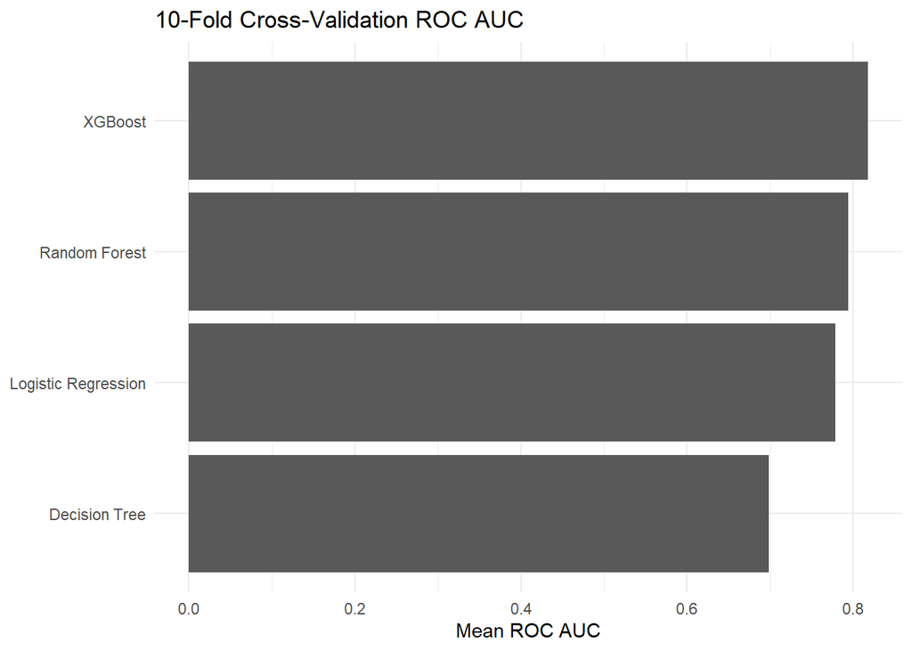

```r
cv_comparison |>
  ggplot(
    aes(
      x = reorder(
        model,
        mean_roc_auc
      ),
      y = mean_roc_auc
    )
  ) +
  geom_col() +
  coord_flip() +
  labs(
    title = "10-Fold Cross-Validation ROC AUC",
    x = NULL,
    y = "Mean ROC AUC"
  ) +
  theme_minimal()
```

# Variable Importance

## XGBoost Variable Importance with VIP

[figure not shown]

```r
final_xgb_fit |>
  workflows::extract_fit_parsnip() |>
  vip::vip(
    num_features = 15
  ) +
  labs(
    title = "XGBoost Variable Importance",
    subtitle = "Importance based on model contribution"
  ) +
  theme_minimal()
```

# PDP

## Prepare Final XGBoost Model for Interpretation

```r
xgb_prep <- prep(
  xgb_rec,
  training = marketing_train
)

xgb_baked <- bake(
  xgb_prep,
  new_data = marketing_train
)

predictor_names <- setdiff(
  names(xgb_baked),
  "Conversion"
)

xgb_matrix <- as.matrix(
  xgb_baked[
    ,
    predictor_names
  ]
)

xgb_engine <- workflows::extract_fit_parsnip(
  final_xgb_fit
)$fit
```

## Partial Dependence Plot for AdSpend

```r
adspend_values <- seq(
  from = quantile(
    marketing_train$AdSpend,
    0.05
  ),
  to = quantile(
    marketing_train$AdSpend,
    0.95
  ),
  length.out = 30
)

pdp_adspend_list <- lapply(
  adspend_values,
  function(value) {

    pd_data <- marketing_train

    pd_data$AdSpend <- value

    pd_baked <- recipes::bake(
      xgb_prep,
      new_data = pd_data
    )

    pd_matrix <- as.matrix(
      pd_baked[
        ,
        predictor_names
      ]
    )

    pd_dmatrix <- xgboost::xgb.DMatrix(
      data = pd_matrix
    )

    pd_prediction <- predict(
      xgb_engine,
      pd_dmatrix
    )

    data.frame(
      AdSpend = value,
      Predicted_Conversion = mean(
        pd_prediction
      )
    )
  }
)

pdp_adspend <- do.call(
  rbind,
  pdp_adspend_list
)

pdp_adspend
```

```
     AdSpend Predicted_Conversion
1   612.7956            0.9135067
2   917.5109            0.9135067
3  1222.2262            0.9160755
4  1526.9414            0.9160755
5  1831.6567            0.9144248
6  2136.3720            0.9123935
7  2441.0873            0.9123944
8  2745.8026            0.9155582
9  3050.5179            0.9161824
10 3355.2331            0.9169997
11 3659.9484            0.9236228
12 3964.6637            0.9194767
13 4269.3790            0.9170445
14 4574.0943            0.9112569
```

[output cut: 16 more lines]

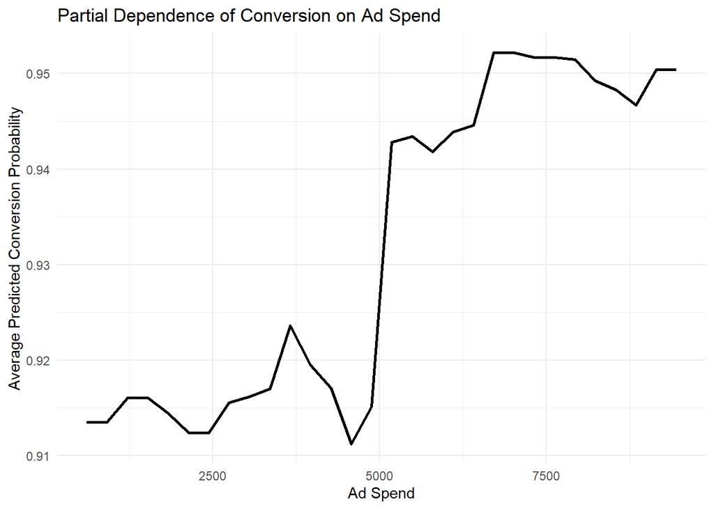

```r
ggplot(
  pdp_adspend,
  aes(
    x = AdSpend,
    y = Predicted_Conversion
  )
) +
  geom_line(
    linewidth = 1
  ) +
  labs(
    title = "Partial Dependence of Conversion on Ad Spend",
    x = "Ad Spend",
    y = "Average Predicted Conversion Probability"
  ) +
  theme_minimal()
```

# SHAP

## SHAP Feature Importance

```r
shap_values <- predict(
  xgb_engine,
  xgb_matrix,
  predcontrib = TRUE
)

shap_matrix <- as.matrix(
  shap_values
)

shap_matrix <- shap_matrix[
  ,
  !colnames(shap_matrix) %in%
    c(
      "BIAS",
      "(Intercept)"
    ),
  drop = FALSE
]

shap_importance <- data.frame(
  Feature = colnames(
    shap_matrix
  ),
  Mean_Abs_SHAP = colMeans(
    abs(shap_matrix)
  )
)

shap_importance <- shap_importance[
  order(
    shap_importance$Mean_Abs_SHAP,
    decreasing = TRUE
  ),
]

head(
  shap_importance,
  15
)
```

```
                                        Feature Mean_Abs_SHAP
CampaignType_Conversion CampaignType_Conversion    0.76948454
EmailClicks                         EmailClicks    0.45464743
PreviousPurchases             PreviousPurchases    0.43894054
ClickThroughRate               ClickThroughRate    0.38743094
LoyaltyPoints                     LoyaltyPoints    0.37611979
PagesPerVisit                     PagesPerVisit    0.36815917
EmailOpens                           EmailOpens    0.36507301
AdSpend                                 AdSpend    0.33514671
TimeOnSite                           TimeOnSite    0.32572873
WebsiteVisits                     WebsiteVisits    0.30199126
SocialShares                       SocialShares    0.11005048
CampaignChannel_Email     CampaignChannel_Email    0.08836605
Age                                         Age    0.08407534
Income                                   Income    0.08113043
CampaignChannel_PPC         CampaignChannel_PPC    0.03948123
```

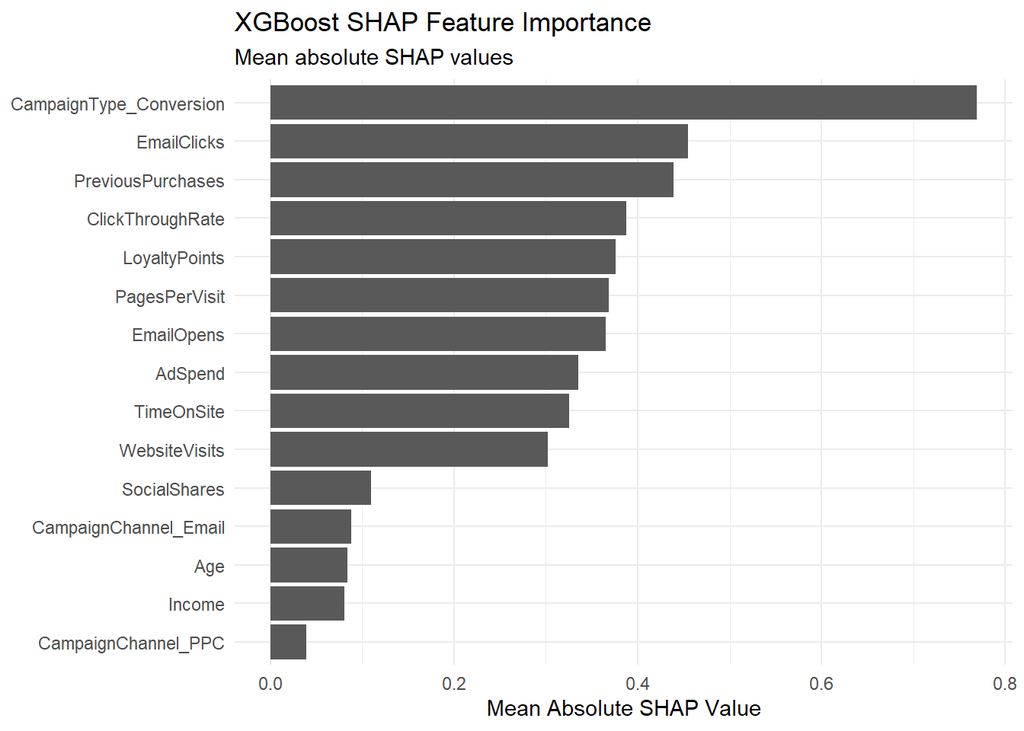

```r
shap_plot_data <- head(
  shap_importance,
  15
)

ggplot(
  shap_plot_data,
  aes(
    x = reorder(
      Feature,
      Mean_Abs_SHAP
    ),
    y = Mean_Abs_SHAP
  )
) +
  geom_col() +
  coord_flip() +
  labs(
    title = "XGBoost SHAP Feature Importance",
    subtitle = "Mean absolute SHAP values",
    x = NULL,
    y = "Mean Absolute SHAP Value"
  ) +
  theme_minimal()
```

# Summary Findings

> Four classification models were compared using 10-fold cross-validation. XGBoost achieved the highest mean ROC AUC (0.818), followed by Random Forest (0.795), Logistic Regression (0.779), and Decision Tree (0.699).

> On the test set, XGBoost also produced the strongest overall performance, with an accuracy of 0.918 and ROC AUC of 0.844. The model maintained very high sensitivity (0.995), while specificity remained lower at 0.374.

> XGBoost variable importance showed that marketing activity and customer engagement variables were among the most useful predictors of customer conversion.

> The partial dependence plot for AdSpend showed a nonlinear relationship. Predicted conversion probability remained relatively stable at lower spending levels, increased around an AdSpend level of approximately 5,000, and then remained relatively high.

> Overall, the results suggest that customer engagement, purchase history, and marketing activity are more useful for predicting conversion than demographic characteristics in this dataset.